# Weight Lifting Exercises

This markdown document predicts how well the subject in “Weight Lifting Exercises Dataset” performed. Original data and more explanations about data can be found at: http://groupware.les.inf.puc-rio.br/har#dataset

As the first step. load the data and clean it. There are a lot of columns with “NA” and also some columns with zero variance which will not be helpful in our prediction.

```r
library(caret)
```

```r
library(corrplot)
setwd('/Users/sahar/Dropbox/Coursera_Sahar_Danial/Practical Machine Learning/Assignment/')
d<-read.csv("./pml-training.csv")
t<-read.csv("./pml-testing.csv")

d[d==""]<-NA
d_n<-d[,colSums(is.na(d)) ==0]
n<-names(d[,colSums(is.na(d)) ==0])
#zero_var<-names(which(apply(d_n,2,var)==0))
#d_n<-d_n[,-which(names(d_n)%in%zero_var)]
d_n<-d_n[,-which(names(d_n)%in%"X")]
```

repeat the exact same process on the final test case to have a clean test case;

```r
t[t==""]<-NA
t_n<-t[,which(names(t)%in%n)]
#t_n<-t_n[,-which(names(t_n)%in%zero_var)]
t_n<-t_n[,-which(names(t_n)%in%"X")]
```

Let’s devide the training data to two groups to be able to evaluate our prediction algorithm and cross validate the prediction:

```r
set.seed(975)
inTrain <- createDataPartition(d_n$classe, p = 0.75, list = FALSE);
train_d_n<-d_n[inTrain,]
test_d_n<-d_n[-inTrain,]
```

scale the data and find out the correlation between features. Remove the ones which are more than 80% correlated

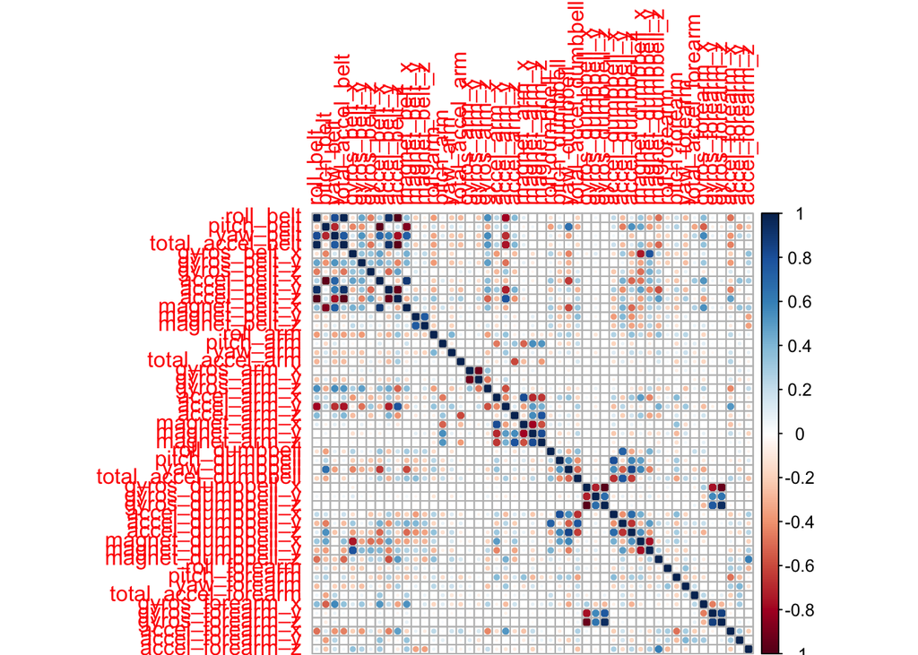

```r
train_d_n.scale<-scale(train_d_n[,7:55],center=TRUE,scale=TRUE)
corr_d_train<-cor(train_d_n.scale)
corrplot(corr_d_train)
```

```r
highCorr <- findCorrelation(corr_d_train, 0.80)
train_d_n<-train_d_n[-highCorr]
test_d_n<-test_d_n[-highCorr]
t_n<-t_n[-highCorr]
```

train the data using the “rpart” method, then perform cross validation to find out how well your prediction works. Tune the parameters to get better results (in this case the thereshold of correlation was changed). I found using threshold=0.7 is not suitable and leads to error but increasing it to 0.8 makes a significant improvement in prediction.

```r
modelFit<-train(classe~.,method="rpart",data=train_d_n)
print(modelFit$finalModel)
```

```
## n= 14718
##
## node), split, n, loss, yval, (yprob)
##       * denotes terminal node
##
##  1) root 14718 10530 A (0.28 0.19 0.17 0.16 0.18)
##    2) roll_belt< 130.5 13501  9324 A (0.31 0.21 0.19 0.18 0.11)
##      4) pitch_forearm< -33.95 1195    10 A (0.99 0.0084 0 0 0) *
##      5) pitch_forearm>=-33.95 12306  9314 A (0.24 0.23 0.21 0.2 0.12)
##       10) cvtd_timestamp02/12/2011 13:33>=0.5 995   256 A (0.74 0.26 0 0 0) *
##       11) cvtd_timestamp02/12/2011 13:33< 0.5 11311  8729 B (0.2 0.23 0.23 0.21 0.13)
##         22) magnet_dumbbell_z< -23.5 4237  2696 A (0.36 0.28 0.095 0.2 0.054) *
##         23) magnet_dumbbell_z>=-23.5 7074  4909 C (0.1 0.2 0.31 0.22 0.18)
##           46) cvtd_timestamp28/11/2011 14:13>=0.5 396     0 A (1 0 0 0 0) *
##           47) cvtd_timestamp28/11/2011 14:13< 0.5 6678  4513 C (0.047 0.21 0.32 0.23 0.19)
##             94) magnet_dumbbell_x< -446.5 4688  2660 C (0.058 0.13 0.43 0.26 0.12) *
##             95) magnet_dumbbell_x>=-446.5 1990  1214 B (0.023 0.39 0.069 0.16 0.35) *
##    3) roll_belt>=130.5 1217     8 E (0.0066 0 0 0 0.99) *
```

```r
predict(modelFit,newdata = test_d_n)
```

[output not shown]

[output cut: 131 more lines]

```r
length(which(predict(modelFit,newdata = test_d_n)==test_d_n$classe))
```

```
## [1] 2642
```

Finally, apply the prediction model to final test set and prepare the accepted format for submitting the output.

```r
predict(modelFit,newdata = t_n)
```

```
##  [1] A A C A A C C C A A C C B A C B B A A B
## Levels: A B C D E
```

```r
answers<-as.character(predict(modelFit,newdata = t_n))
pml_write_files = function(x){
        n = length(x)
        for(i in 1:n){
                filename = paste0("problem_id_",i,".txt")
                write.table(x[i],file=filename,quote=FALSE,row.names=FALSE,col.names=FALSE)
                }
        }
pml_write_files(answers)
```